# A5

McKenzie Kozma

9/30/2019

1. Clean the data for easy graphing.

```r
library(tidyverse)
library(readxl)

c2015 <- read_xlsx("c2015.xlsx")

c2015.clean <- c2015 %>%
  drop_na() %>%
  filter_all(~!(.=='Unknown')) %>%
  filter_all(~!(.=='Not Rep')) %>%
  filter_all(~!(.==str_detect(.,'Not Rep'))) %>%
  filter_all(~!(.==str_detect(.,'Unknown'))) %>%
  filter_all(~!(.=='Not Reported')) %>%
  filter(SEAT_POS=='Front Seat, Left Side') %>%
  mutate(AGE = as.numeric(AGE),
         TRAV_SP = ifelse(TRAV_SP == "Stopped", 0, as.numeric(str_remove(TRAV_SP, "MPH"))))
```

2. Use geom_point to plot AGE and TRAV_SP coloring by SEX.

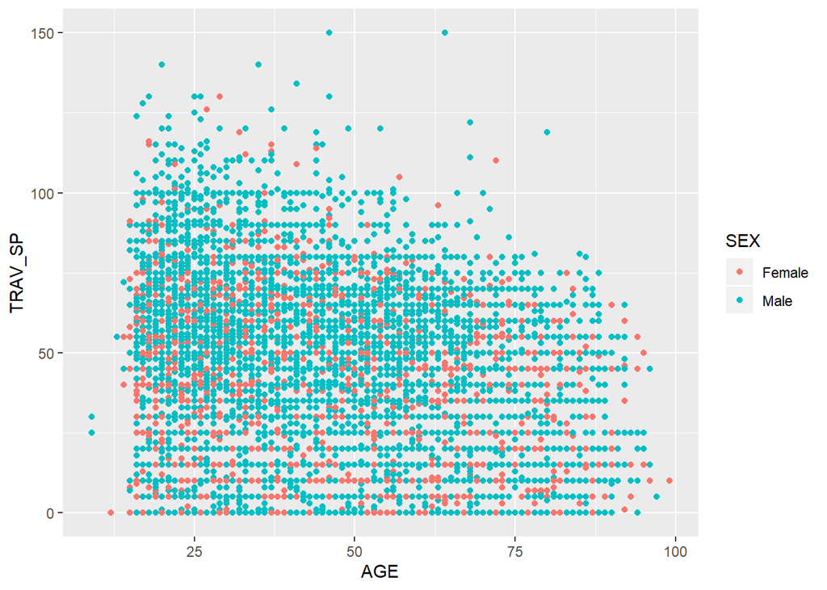

```r
c2015.clean %>%
  ggplot(aes(AGE, TRAV_SP, col = SEX)) +
  geom_point()
```

3. There is overplotting in 2. Overplotting is when many points are duplicated on the graph. Use geom_jitter instead of geom_point for 2. to avoid overplotting.

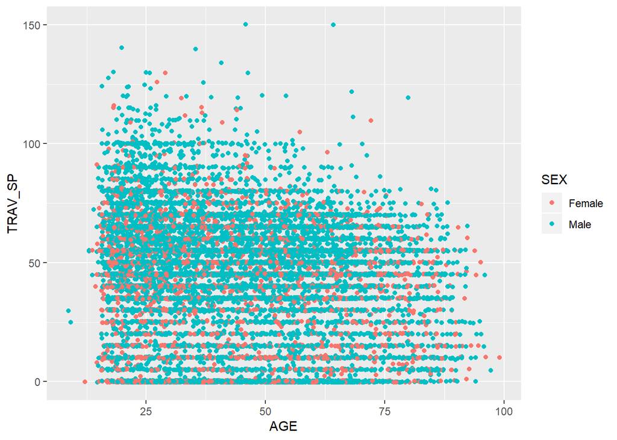

```r
c2015.clean %>%
  ggplot(aes(AGE, TRAV_SP, col = SEX)) +
  geom_jitter()
```

4. Plot histograms of AGE, TRAV_SP with bins = 50.

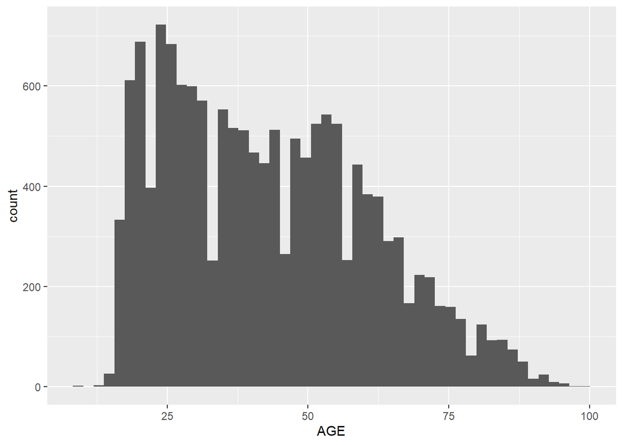

```r
c2015.clean %>%
  ggplot(aes(AGE)) +
  geom_histogram(bins = 50)
```

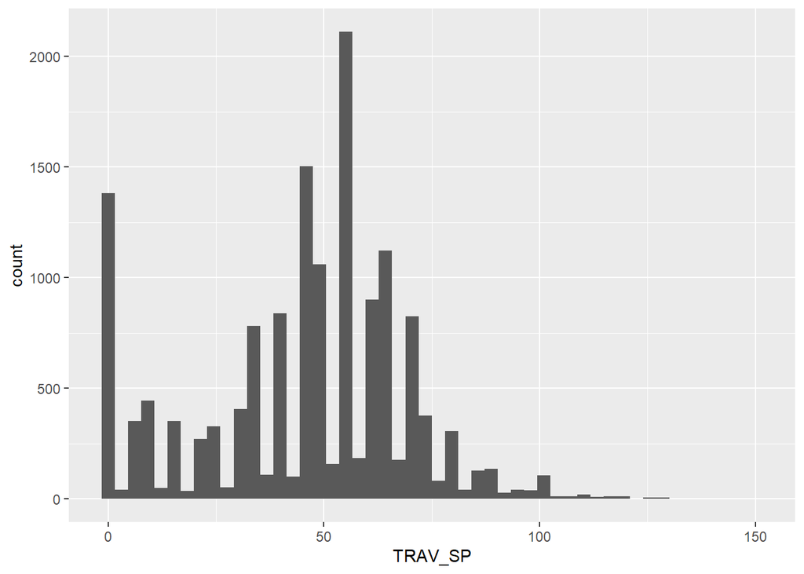

```r
c2015.clean %>%
  ggplot(aes(TRAV_SP)) +
  geom_histogram(bins = 50)
```

5. Plot a histogram of AGE coloring (fill) by SEX.

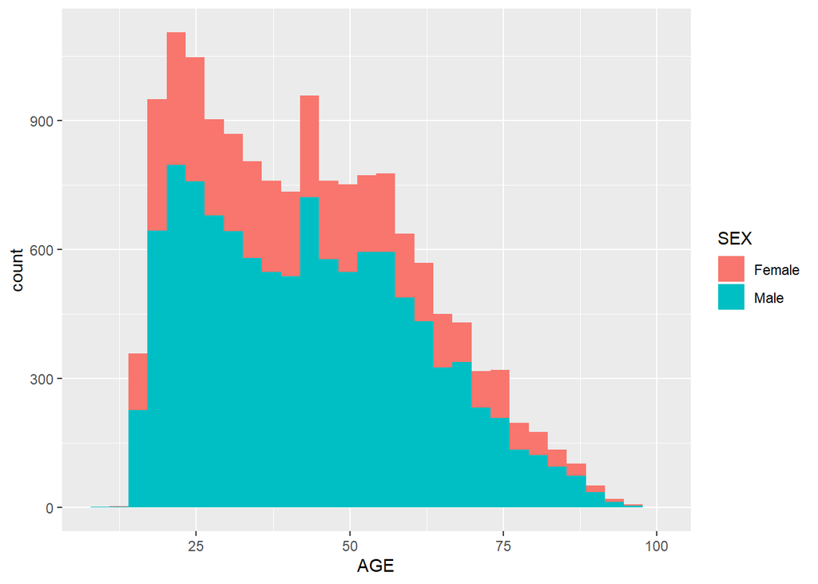

```r
c2015.clean %>%
  ggplot(aes(AGE, fill = SEX)) +
  geom_histogram()
```

6. Using geom_density to plot estimated densities of AGE colored by SEX.

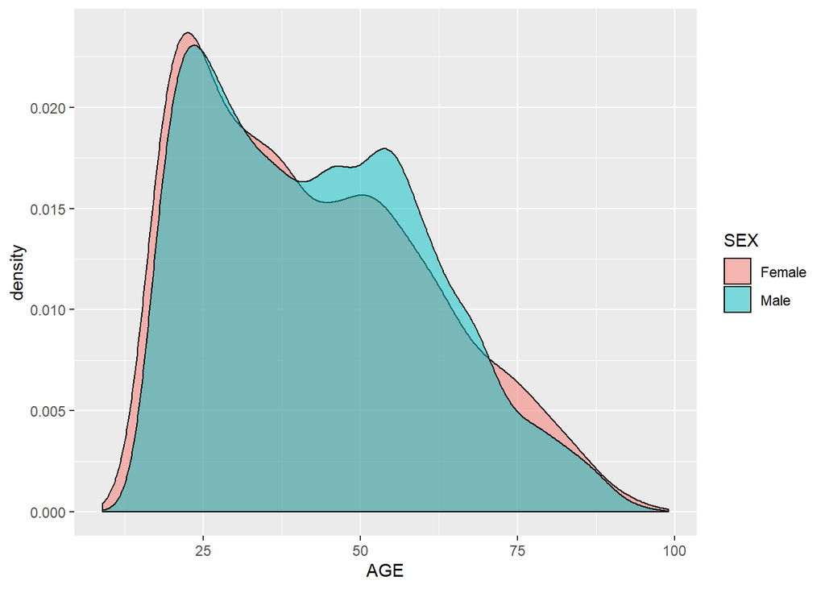

```r
c2015.clean %>%
  ggplot(aes(AGE, fill = SEX)) +
  geom_density(alpha = 0.5)
```

7. Plot estimated densities of TRAV_SP colored by INJ_SEV.

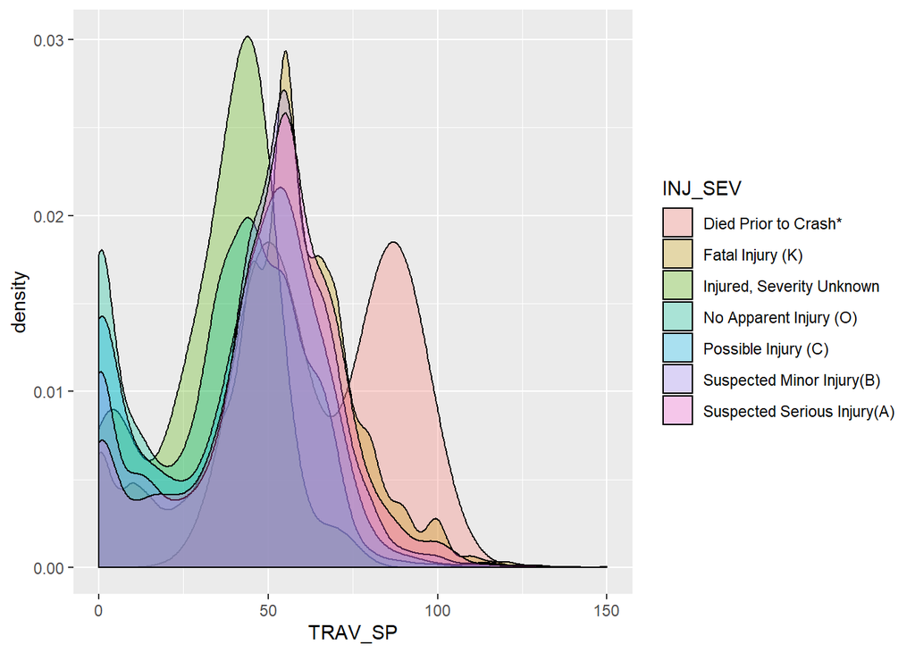

```r
c2015.clean %>%
  ggplot(aes(TRAV_SP, fill = INJ_SEV)) +
  geom_density(alpha = 0.3)
```

8. Plot estimated densities of TRAV_SP seperated (colored) by weekdays and weekends.

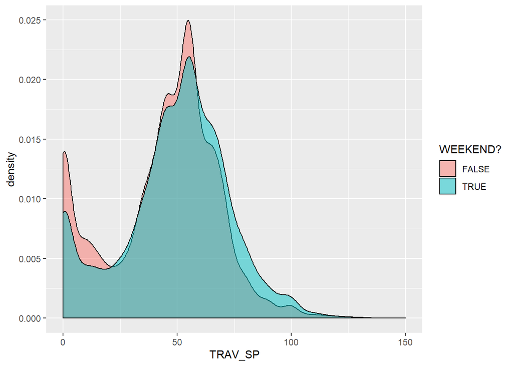

```r
c2015.clean %>%
  ggplot(aes(TRAV_SP, fill = DAY_WEEK %in% c("Saturday", "Sunday"))) +
  geom_density(alpha = 0.5) +
  labs(fill = "WEEKEND?")
```

9. Implement geom_bar on MONTH. Implement geom_bar on MONTH filled by SEX

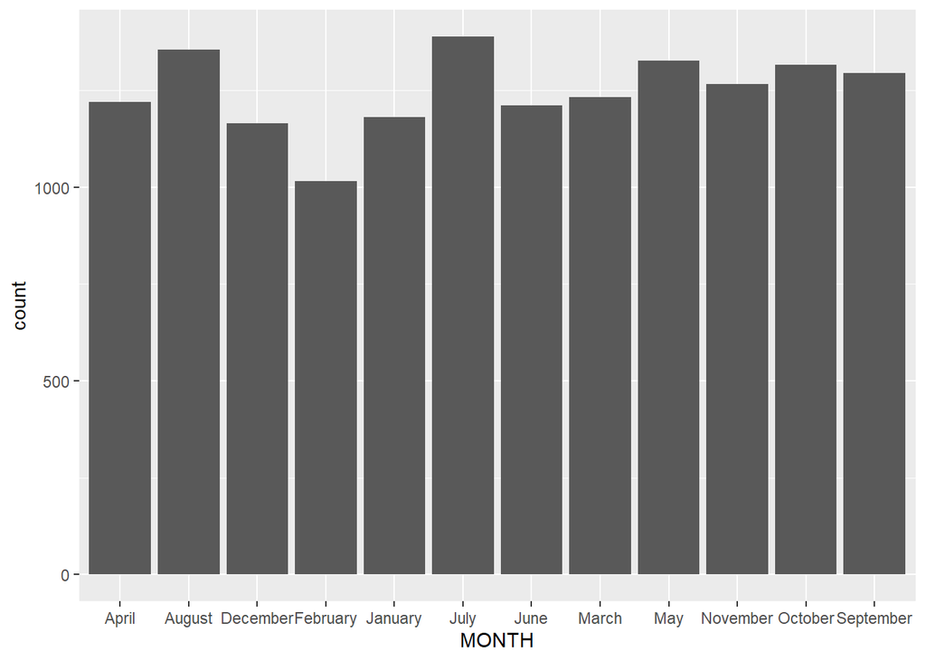

```r
c2015.clean %>%
  ggplot(aes(MONTH)) +
  geom_bar()
```

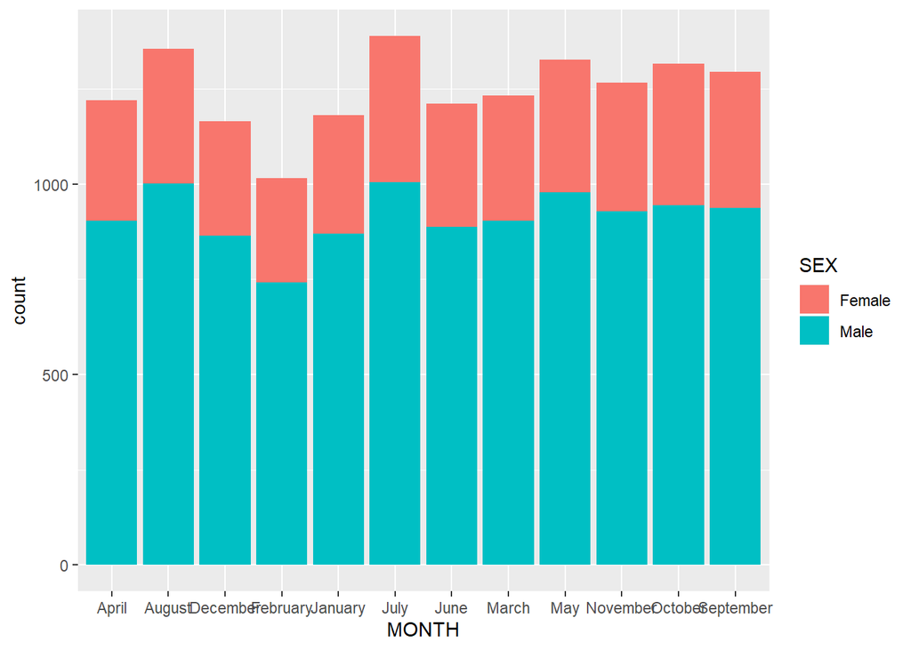

```r
c2015.clean %>%
  ggplot(aes(MONTH, fill = SEX)) +
  geom_bar()
```

10. Implement geom_bar on MONTH and SEX with position=‘dodge’

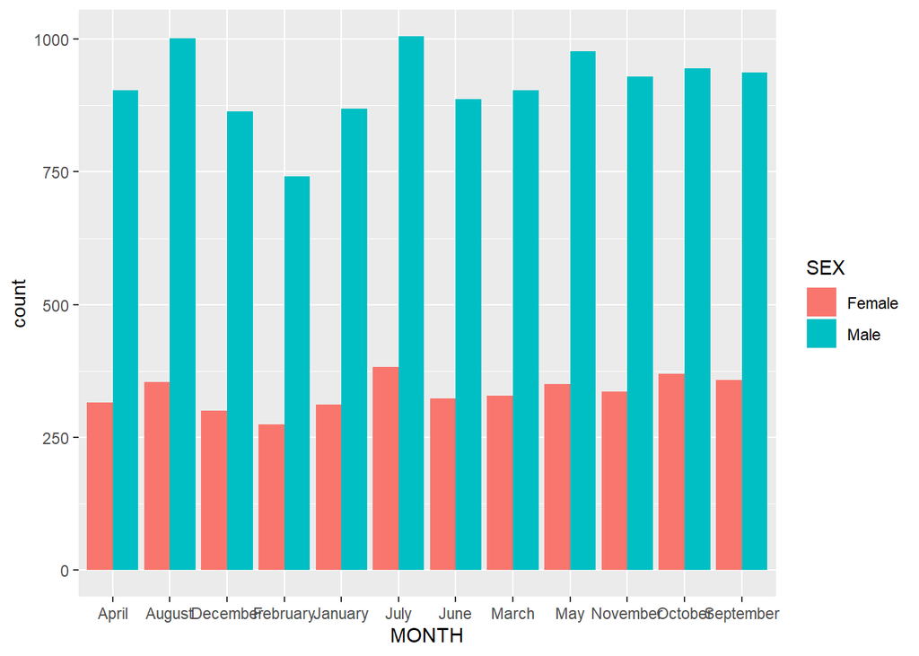

```r
c2015.clean %>%
  ggplot(aes(MONTH, fill = SEX)) +
  geom_bar(position = "dodge")
```

11. Plot a bar chart of average speeds in months using geom_col

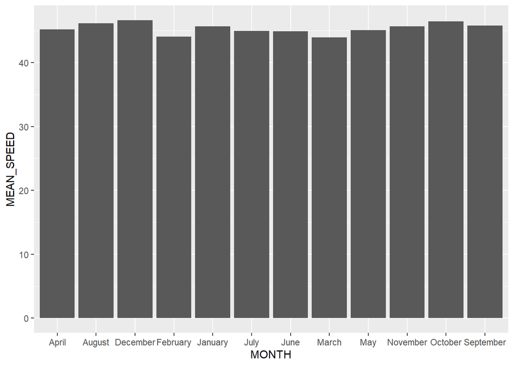

```r
avg.speed <- c2015.clean %>%
  group_by(MONTH) %>%
  summarise(MEAN_SPEED = mean(TRAV_SP))

avg.speed %>%
  ggplot(aes(MONTH, MEAN_SPEED)) +
  geom_col()
```

12. Plot a bar chart of average speeds in months using geom_bar

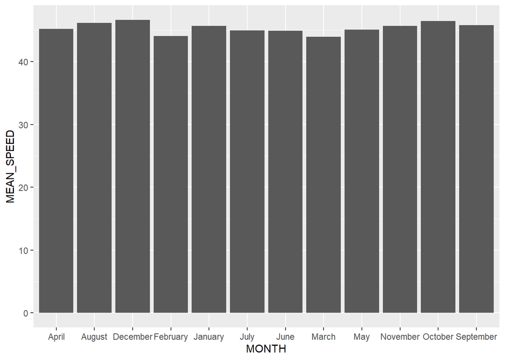

```r
avg.speed %>%
  ggplot(aes(MONTH, MEAN_SPEED)) +
  geom_bar(stat = "identity")
```

13. Plot a bar chart of average speeds in months filled by SEX

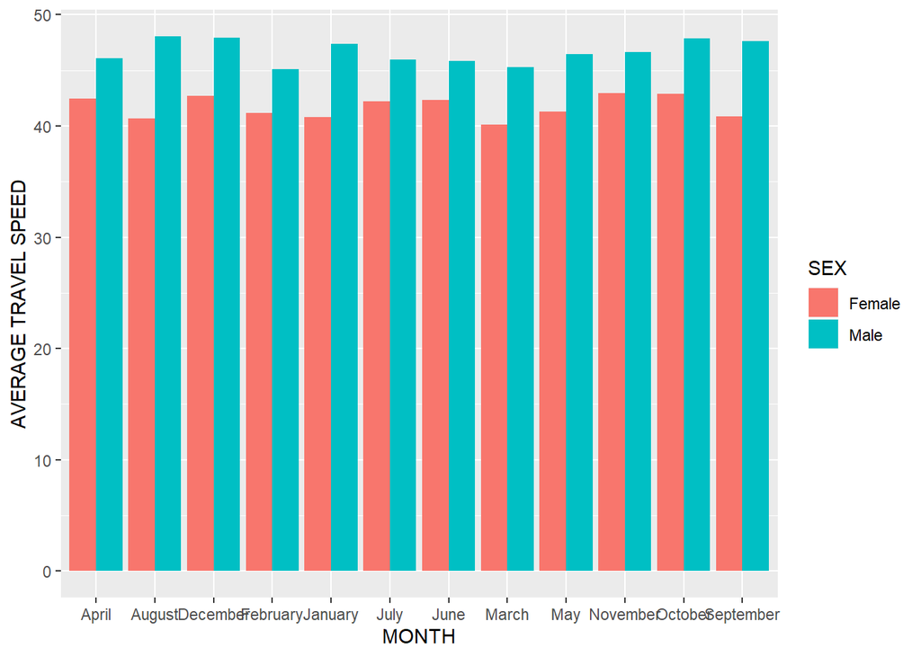

```r
c2015.speedbysex <- c2015.clean %>%
  group_by(MONTH, SEX) %>%
  summarise(AVG_SPEED = mean(TRAV_SP))

c2015.speedbysex %>% ggplot(aes(MONTH, AVG_SPEED, fill = SEX)) +
  geom_col(position = "dodge") +
  labs(y = "AVERAGE TRAVEL SPEED")
```

14. Plot a bar chart of average speeds in months colored by INJ_SEV

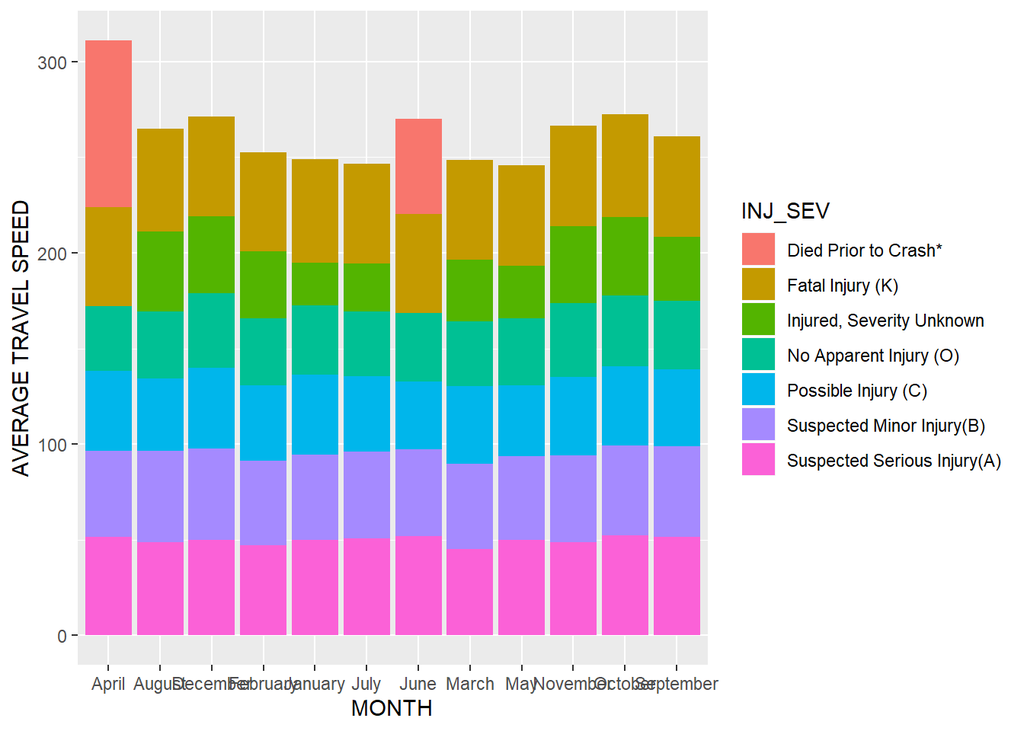

```r
c2015.speedbysev <- c2015.clean %>%
  group_by(MONTH, INJ_SEV) %>%
  summarise(AVG_SPEED = mean(TRAV_SP))

c2015.speedbysev %>% ggplot(aes(MONTH, AVG_SPEED, fill = INJ_SEV)) +
  geom_col() +
  labs(y = "AVERAGE TRAVEL SPEED")
```

15. Refer to this link to have a similar following plot: Horizontal axis is for (monthly) average speed The vertical axis is for months Color by two colors: one for above overall average speed and the other for below the avarage speed The speed on the horizontal axis is standardized

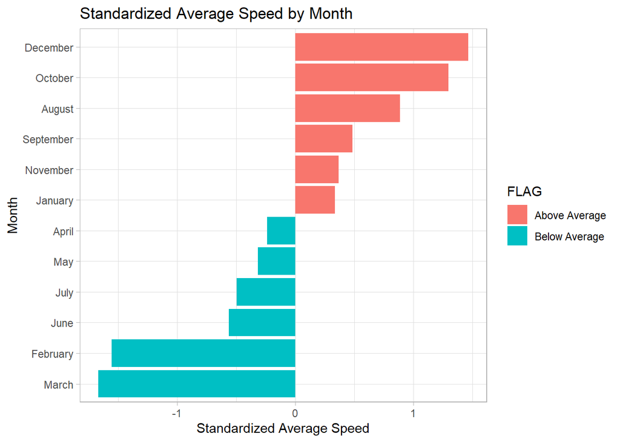

```r
c2015.bar <- c2015.clean %>%
  group_by(MONTH) %>%
  summarise(SPEED = mean(TRAV_SP)) %>%
  mutate(STD_SP = (SPEED - mean(SPEED)) / sd(SPEED),
         FLAG = ifelse(SPEED > mean(SPEED), "Above Average", "Below Average"))

c2015.bar %>%
  ggplot(aes(reorder(MONTH, STD_SP), STD_SP, fill = FLAG)) +
  geom_col() +
  labs(x = "Month", y = "Standardized Average Speed",
       title = "Standardized Average Speed by Month") +
  theme(legend.title = element_blank()) +
  coord_flip() +
  theme_light()
```

16. Refer to this link to have a similar following plot: Horizontal Axis is for mean speed Vertical Axis is for INJ_SEV Color by SEX The numbers of speed are shown in points.

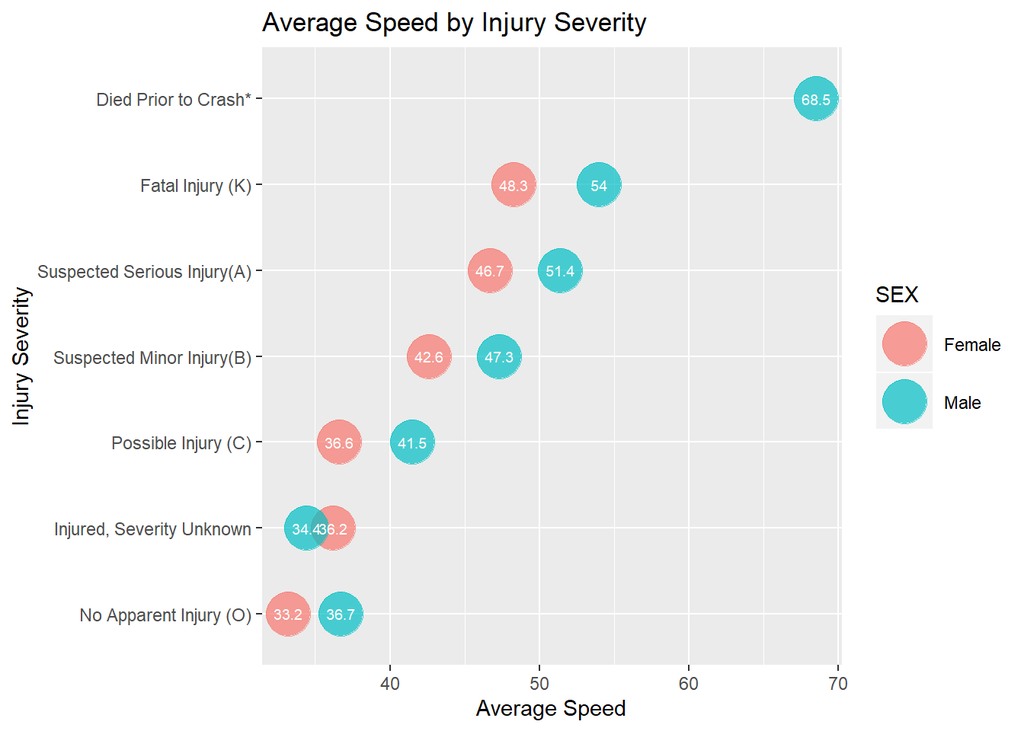

```r
c2015.dot <- c2015.clean %>%
  group_by(INJ_SEV, SEX) %>%
  summarise(SPEED = round(mean(TRAV_SP), 1))

c2015.dot %>%
  ggplot(aes(reorder(INJ_SEV, SPEED), SPEED, label = SPEED, col = SEX)) +
  geom_point(size = 10, alpha = 0.7) +
  geom_text(color = "white", size = 2.5) +
  labs(x = "Injury Severity", y = "Average Speed",
       title = "Average Speed by Injury Severity") +
  coord_flip()
```

17. Refer to this link to have a similar following plot: Horizontal Axis is for speed Vertical Axis is for DAY Color by SEX The should be a invisible vertical line seperating the two sexes.

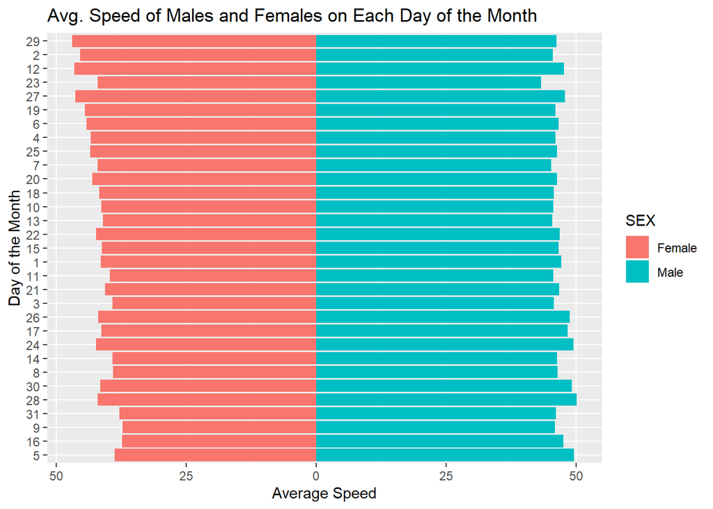

```r
c2015.pyramid <- c2015.clean %>%
  group_by(DAY, SEX) %>%
  summarise(AVG_SPEED = mean(TRAV_SP)) %>%
  mutate(AVG_SPEED = ifelse(SEX == "Female", -AVG_SPEED, AVG_SPEED))

c2015.pyramid %>%
  ggplot(aes(reorder(DAY, -AVG_SPEED), AVG_SPEED, fill = SEX))+
  geom_col() +
  scale_y_continuous(labels = str_c(as.character(c(seq(50, 0, -25), seq(25, 50, 25))))) +
  labs(x = "Day of the Month", y = "Average Speed", title = "Avg. Speed of Males and Females on Each Day of the Month") +
  coord_flip()
```

18-20. Generate three other interesting graphs from the dataset.

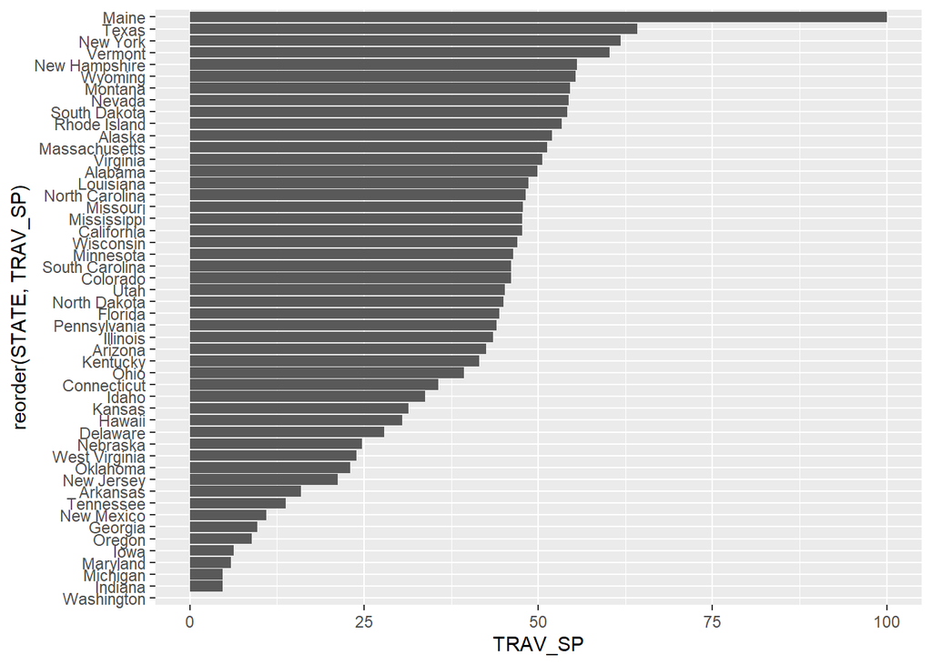

```r
c2015.clean %>%
  ggplot(aes(reorder(STATE, TRAV_SP), TRAV_SP)) +
  stat_summary(fun.y = mean, geom = "bar") +
  coord_flip()
```

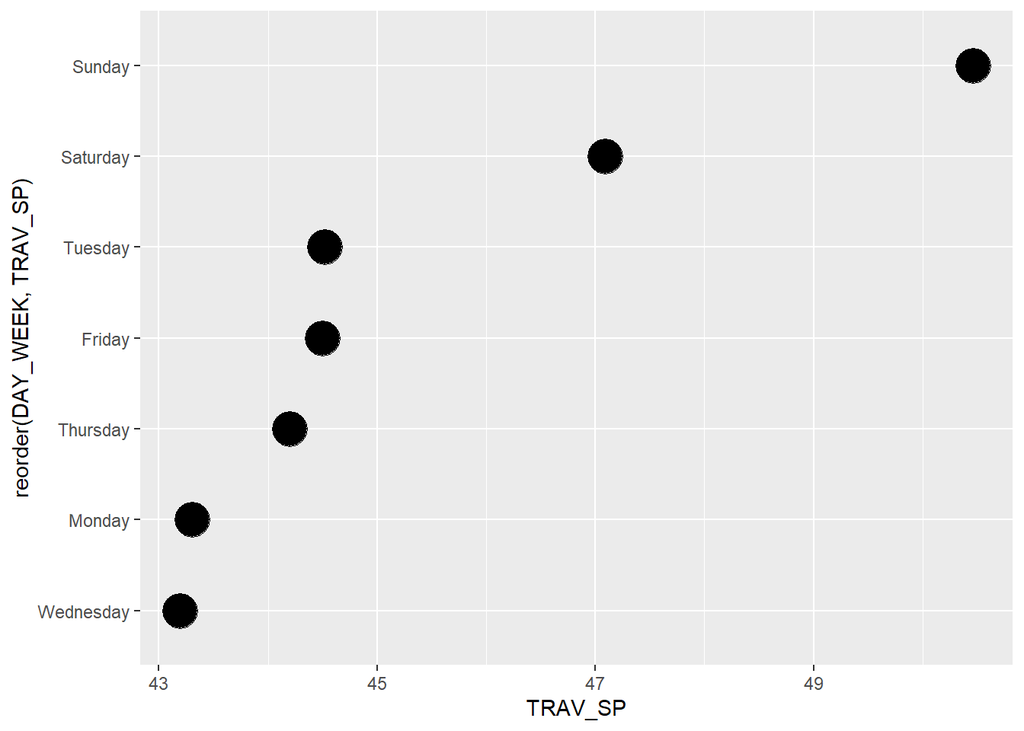

```r
c2015.clean %>%
  ggplot(aes(reorder(DAY_WEEK, TRAV_SP), TRAV_SP)) +
  stat_summary(fun.y = mean, geom = "point", size = 8) +
  coord_flip()
```

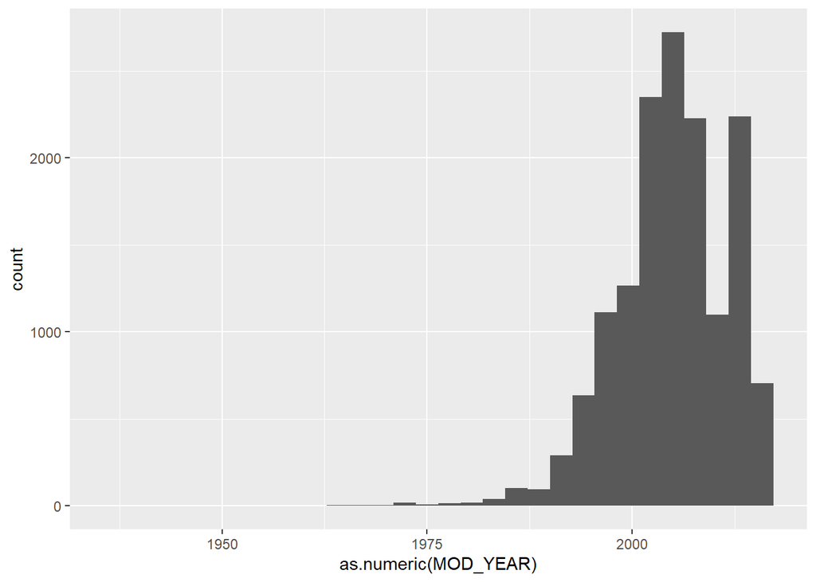

```r
c2015.clean %>%
  ggplot(aes(as.numeric(MOD_YEAR))) +
  geom_histogram()
```